# Homework 3

Shyni David

3/13/2019

Code up a version of the Gibbs sampler for the binary probit model specified as follows: y=I(z>0) z=Xδ+ε; ε~ iid N(0,σ^2 ) σ^2~(υ_0 s_0<sup>2)/(χ_(υ_0)</sup>2 ); δ~N(δ ̅,A^(-1) ) Note: you can pattern your code after the bayesm function rbprobitGibbs. δ is not identified in the model above, but beta=δ/σ is. Your Gibbs sampler will generate draws of (δ,σ2). You can simply divide the draws of δ by the σ draw to infer about the identified quantity, beta.

Use the routine in the help file for rbprobitGibbs to generate data from the binary probit model with σ=1, and compare the Gibbs sampler defined in this problem with the Gibbs sampler defined in rbprobitGibbs. Which is better? Why?

```r
 rm(list=ls(all=TRUE))
 library(bayesm)
 setwd("~/Desktop/FISHER SMB-A/Term 4/Bayes/Week 3")
 source("Hw3Q1-3.R")

 set.seed(66)
 simbprobit=
 function(X,beta) {
     ##  function to simulate from binary probit including x variable
     y=ifelse((X%*%beta+rnorm(nrow(X)))<0,0,1)
     list(X=X,y=y,beta=beta)
     }

 nobs=150
 X=cbind(rep(1,nobs),runif(nobs),runif(nobs))
 delta=c(-3,3,6)
 nvar=ncol(X)
 simout=simbprobit(X,delta)

 Data=list(X=simout$X,y=simout$y)
 Prior=list(deltabar = c(rep(0, nvar)),A = diag(rep(0.01, nvar)),nu=3,ssq=1)
 Mcmc=list(R=2000,keep=10)

 #
 # draw both delta and sigmasq (HW4Q1.R)
 #
 outfree=myprobit(Data, Prior, Mcmc)
```

```
## MCMC Iteration (est time to end - min)
##   100  ( 0 )
##   200  ( 0 )
##   300  ( 0 )
##   400  ( 0 )
##   500  ( 0 )
##   600  ( 0 )
##   700  ( 0 )
##   800  ( 0 )
##   900  ( 0 )
##   1000  ( 0 )
##   1100  ( 0 )
##   1200  ( 0 )
##   1300  ( 0 )
##   1400  ( 0 )
##   1500  ( 0 )
##   1600  ( 0 )
##   1700  ( 0 )
##   1800  ( 0 )
##   1900  ( 0 )
##   2000  ( 0 )
##   Total Time Elapsed:  0
```

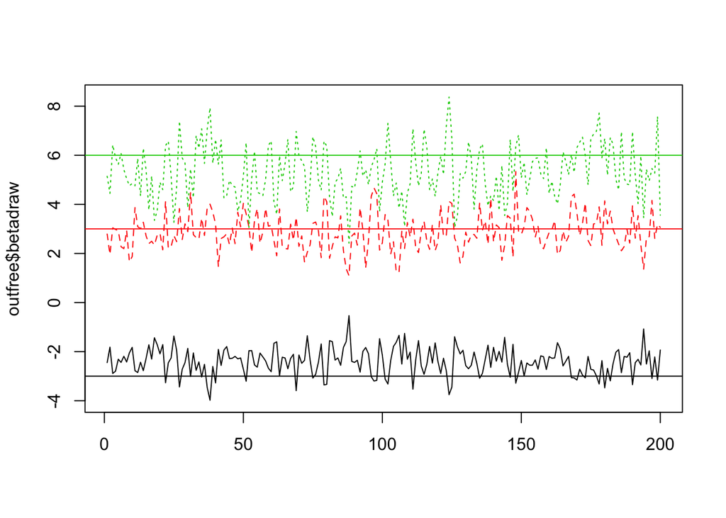

```r
 matplot(outfree$betadraw,type="l",col=c(1:nvar))
 for(b in 1: nvar){
 abline(delta[b],0,col=b)
 }
```

```r
 #
 # only draw delta and fix sigmasq=1 (rbprobitGibbs)
 #
out=rbprobitGibbs(Data, Prior, Mcmc)
```

```
##
## Starting Gibbs Sampler for Binary Probit Model
##    with  150  observations
## Table of y Values
## y
##   0   1
##  30 120
##
## Prior Parms:
## betabar
## [1] 0 0 0
## A
##      [,1] [,2] [,3]
## [1,] 0.01 0.00 0.00
## [2,] 0.00 0.01 0.00
## [3,] 0.00 0.00 0.01
##
## MCMC parms:
## R=  2000  keep=  10  nprint=  100
##
##  MCMC Iteration (est time to end - min)
##  100 (0.0)
##  200 (0.0)
##  300 (0.0)
##  400 (0.0)
##  500 (0.0)
##  600 (0.0)
##  700 (0.0)
##  800 (0.0)
##  900 (0.0)
##  1000 (0.0)
##  1100 (0.0)
##  1200 (0.0)
##  1300 (0.0)
##  1400 (0.0)
##  1500 (0.0)
##  1600 (0.0)
##  1700 (0.0)
##  1800 (0.0)
##  1900 (0.0)
##  2000 (0.0)
##  Total Time Elapsed: 0.00
```

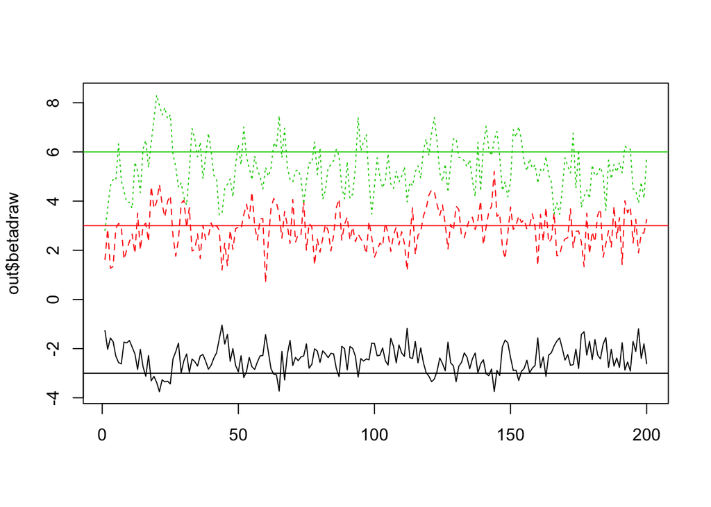

```r
 matplot(out$betadraw,type="l",col=c(1:nvar))
 for(b in 1: nvar){
 abline(delta[b],0,col=b)
 }
```

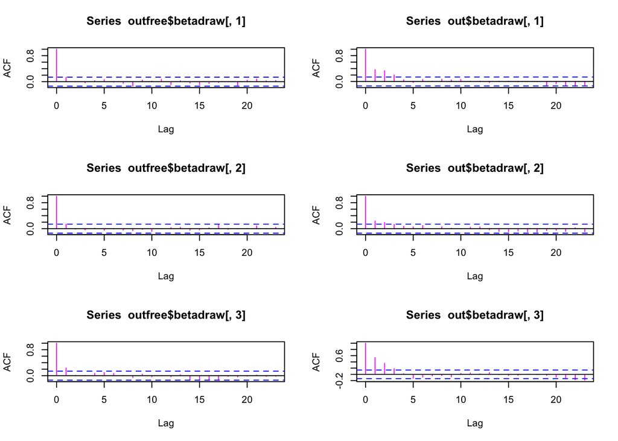

```r
 #
 # plot acf
 #
par(mfcol=c(3,2))
acf(outfree$betadraw[,1], col="magenta")
acf(outfree$betadraw[,2], col="magenta")
acf(outfree$betadraw[,3], col="magenta")
acf(out$betadraw[,1], col="magenta")
acf(out$betadraw[,2], col="magenta")
acf(out$betadraw[,3], col="magenta")
```

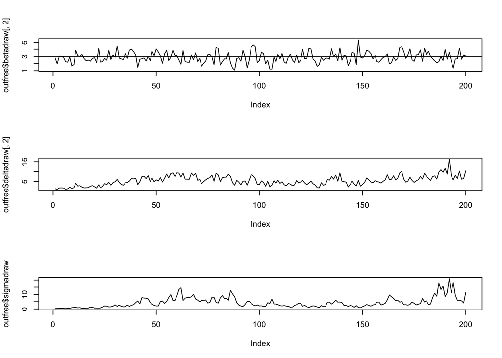

```r
#
# the mixing property of unidentified parameters and
# the identified parameters
#
par(mfcol=c(3,1))
plot(outfree$betadraw[,2],type="l")
abline(delta[2],0)
plot(outfree$deltadraw[,2],type="l")
plot(outfree$sigmadraw,type="l")
```

To test the Gibbs sampler for this model, we fisrt simulate data and as σ^2is not identified in Probit model so we can make inference on beta=δ/σ.

To see why the fully specified probit performs better, lets look at ACF plots. ACF determines how dependent or independent the MArkov chain is. Lower autocorelation shows that it is more efficient in estimating the posterior with accuracy. The ACF for rpobitGibbs s higher. High autocorelation means the sampler does not mix well. For the posterior mean, the MCMC error will be lower for weakly corelated samples.

When we look at the mixing properties of the identfied and unidentified parameters, it is clear that even though delta and gamma(unidentified parameters) donot seem to mix, beta is mixing relatively well.